# Linear mixed models

Fitting fixed and random effects

Author

Affiliation

Daniela Palleschi

Humboldt-Universität zu Berlin

Published

April 13, 2023

# Learning objectives

Today we will learn…

- how to add random effects to our models
- how to interpret random-effects models

# Resources

Ch. 14 in Winter (2014)

# Set-up

```r
# suppress scientific notation
options(scipen=999)
```

## 0.1 Packages

```r
pacman::p_load(
  tidyverse,
  here,
  broom,
  broom.mixed,
  lme4,
  lmerTest,
  knitr,
  kableExtra,
  gt,
  patchwork,
  afex,
  ggbeeswarm,
  emmeans
)
```

## 0.2 Data

```r
# load in dataset
df_crit_verb <-
  readr::read_csv(
    here::here("data/tidy_data_lifetime_pilot.csv"),
    # for special characters
    locale = readr::locale(encoding = "latin1")
  ) |>
  mutate_if(is.character, as.factor) |> # all character variables as factor
  mutate(lifetime = fct_relevel(lifetime, "living", "dead"), # order fixed factors
         tense = fct_relevel(tense, "PP", "SF")) |>
  filter(type == "critical", # only critical trials
         px != "px3", # px3 had a lot of missing values
         fp > 0, # only values of fp above 0
         region == "verb") %>% # critical region only
  droplevels() # remove any factor levels with no observations
```

## 0.3 Functions

`format_pval()` to create nicely formatted p-values

```r
# source: https://stackoverflow.com/questions/37470202/in-line-code-for-reporting-p-values-001-in-r-markdown

pacman::p_load(broman) # for myround() function

format_pval <- function(x){
  if (x < .001) return(paste('<', '.001'))
  if (x < .01) return(paste('<', '.01'))
  if (x < .05) return(paste('<', '.05'))
  paste('=', myround(x, 3))  # if above .05, print p-value to 3 decimalp points
}
```

`make_stars()` to add p-value indications

```r
make_stars <- function(pval) {
  stars = ""
  if(pval <= 0.001)
    stars = "***"
  if(pval > 0.001 & pval <= 0.01)
    stars = "**"
  if(pval > 0.01 & pval <= 0.05)
    stars = "*"
  if(pval > 0.05 & pval <= 0.1)
     stars = "."
  stars
}
```

## 0.4 Contrasts

Sum contrast coding: `+/-0.5`

```r
contrasts(df_crit_verb$lifetime) <- c(-0.5,+0.5)
contrasts(df_crit_verb$tense) <- c(-0.5,+0.5)
```

```r
df_crit_verb %>% pull(lifetime) %>% contrasts()
```

```
       [,1]
living -0.5
dead    0.5
```

```r
df_crit_verb %>% pull(tense) %>% contrasts()
```

```
   [,1]
PP -0.5
SF  0.5
```

# 1 (Linear) Mixed models

- linear mixed-effects models (LMEMs)
- linear mixed models (LMMs)
- hierarchical models
- hierarchical linear regression
- etc., etc…

## 1.1 When to use LMMs

- when data are not independent
  - i.e., when you have *grouping* factors
  - i.e., in repeated measures design
  - i.e., when you have multiple data points per e.g., participant and/or item
- since groups constitute *categories*, random effects have to be categorical
- the power of the mixed model is that it allows us to take into account grouping factors when calculating residuals

## 1.2 What is ‘mixed’?

- fixed effects and random effects
- Fixed effects
  - independent variables
  - systematic variability
  - what we can explain/have specific predictions for
- Random effects
  - random variability
  - grouping variables
  - what we cannot explain/have specific predictions for

# 2 `lme4`

- the function `lmer()` specifies mixed models
  - fixed effects (our predictors)
  - random effects

```r
df_crit_verb %>%
  lmer(log(fp) ~ lifetime*tense,
       data = .)
```

```
Error: No random effects terms specified in formula
```

- if we try to run `lmer()` without specifying any random effects, we get a helpful warning

## 2.1 Random effects

- what are random effects?
  - intercept
  - slope
  - their interaction
- imagine we collect reaction times to some task across trials, and we have three participants
  - each participant will have their own average reaction time (intercept)
  - and will differ in regards to whether/how much they speed up or slow down across trials (slopes)

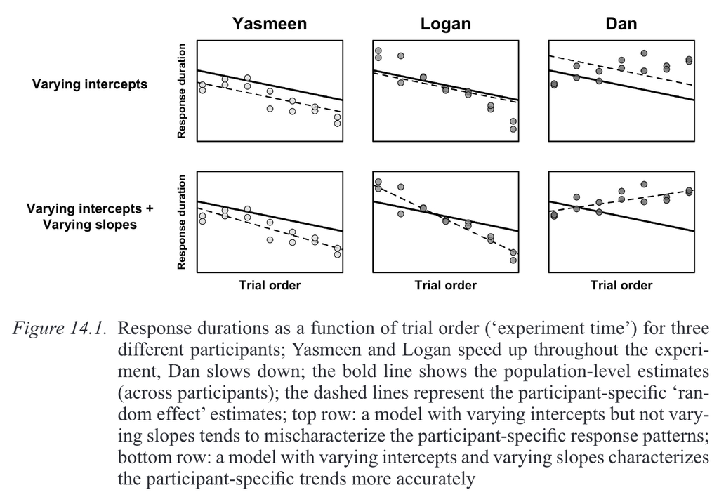

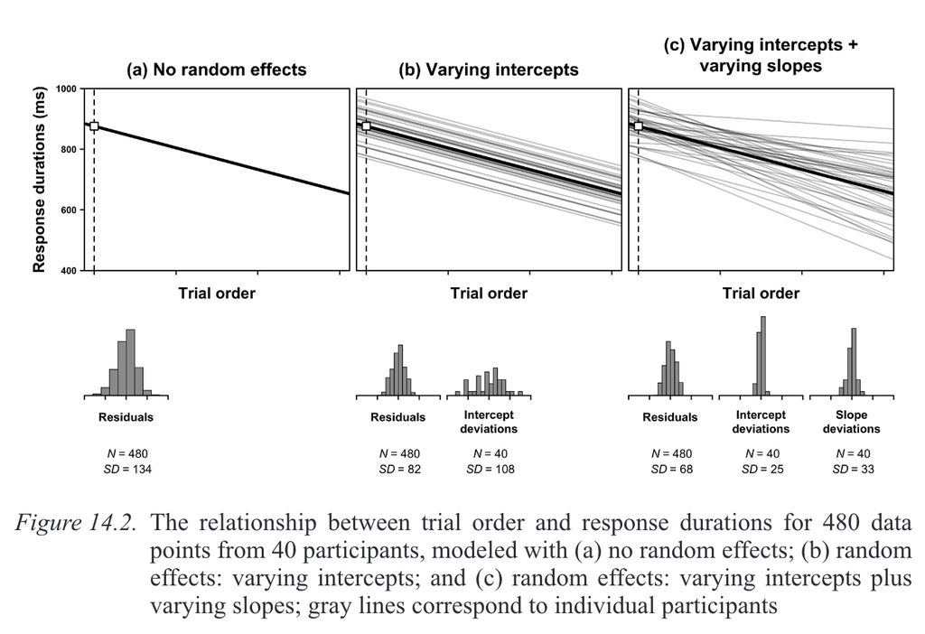

## 2.2 Specifying random effects

- we say *by-participant and by-item varying intercepts and slopes*
  - how do we write this?

| term | interpretation |
| --- | --- |
| (1\|participant) | by-participant varying intercepts (1 = intercept) |
| (1 + lifetime \| participant) | by-participant varying intercepts and lifetime slopes, and their correlation (\|) |
| (1 + lifetime + tense \| participant) | by-participant varying intercepts and slopes for lifetime and tense, and the correlation between slopes and intercepts (\|) |
| (1 + lifetime + tense \|\| participant) | by-participant varying intercepts and slopes for lifetime and tense, with no correlation (\|\|) |

# 3 Fitting random intercepts

```r
fit_fp_mixed <-
  df_crit_verb %>%
  lmer(log(fp) ~ lifetime*tense +
         (1|px),
       data = .,
       REML = F)
```

```r
summary(fit_fp_mixed)
```

```
Linear mixed model fit by maximum likelihood . t-tests use Satterthwaite's
  method [lmerModLmerTest]
Formula: log(fp) ~ lifetime * tense + (1 | px)
   Data: .

     AIC      BIC   logLik deviance df.resid
   580.3    606.0   -284.1    568.3      537

Scaled residuals:
     Min       1Q   Median       3Q      Max
-3.12608 -0.73428  0.01785  0.69800  2.83360

Random effects:
 Groups   Name        Variance Std.Dev.
 px       (Intercept) 0.02883  0.1698
 Residual             0.16103  0.4013
Number of obs: 543, groups:  px, 7

Fixed effects:
                  Estimate Std. Error        df t value         Pr(>|t|)
(Intercept)        5.63218    0.06644   7.00093  84.767 0.00000000000835 ***
lifetime1          0.10224    0.03445 536.01289   2.968          0.00313 **
tense1            -0.03603    0.03445 536.04118  -1.046          0.29619
lifetime1:tense1  -0.09211    0.06891 536.04409  -1.337          0.18186
---
Signif. codes:  0 '***' 0.001 '**' 0.01 '*' 0.05 '.' 0.1 ' ' 1

Correlation of Fixed Effects:
            (Intr) liftm1 tense1
lifetime1    0.000
tense1       0.001  0.013
liftm1:tns1  0.003  0.002 -0.002
```

## 3.1 Compare to MLM

```r
fit_fp <-
  df_crit_verb %>%
  lm(log(fp) ~ lifetime*tense,
       data = .)
```

```r
summary(fit_fp)
```

```
Call:
lm(formula = log(fp) ~ lifetime * tense, data = .)

Residuals:
     Min       1Q   Median       3Q      Max
-1.18141 -0.34282  0.00058  0.26923  1.38822

Coefficients:
                 Estimate Std. Error t value             Pr(>|t|)
(Intercept)       5.63477    0.01877 300.193 < 0.0000000000000002 ***
lifetime1         0.10130    0.03754   2.698              0.00718 **
tense1           -0.03357    0.03754  -0.894              0.37158
lifetime1:tense1 -0.08320    0.07508  -1.108              0.26828
---
Signif. codes:  0 '***' 0.001 '**' 0.01 '*' 0.05 '.' 0.1 ' ' 1

Residual standard error: 0.4374 on 539 degrees of freedom
Multiple R-squared:  0.01712,   Adjusted R-squared:  0.01165
F-statistic: 3.129 on 3 and 539 DF,  p-value: 0.02538
```

```r
summary(fit_fp_mixed)
```

```
Linear mixed model fit by maximum likelihood . t-tests use Satterthwaite's
  method [lmerModLmerTest]
Formula: log(fp) ~ lifetime * tense + (1 | px)
   Data: .

     AIC      BIC   logLik deviance df.resid
   580.3    606.0   -284.1    568.3      537

Scaled residuals:
     Min       1Q   Median       3Q      Max
-3.12608 -0.73428  0.01785  0.69800  2.83360

Random effects:
 Groups   Name        Variance Std.Dev.
 px       (Intercept) 0.02883  0.1698
 Residual             0.16103  0.4013
Number of obs: 543, groups:  px, 7

Fixed effects:
                  Estimate Std. Error        df t value         Pr(>|t|)
(Intercept)        5.63218    0.06644   7.00093  84.767 0.00000000000835 ***
lifetime1          0.10224    0.03445 536.01289   2.968          0.00313 **
tense1            -0.03603    0.03445 536.04118  -1.046          0.29619
lifetime1:tense1  -0.09211    0.06891 536.04409  -1.337          0.18186
---
Signif. codes:  0 '***' 0.001 '**' 0.01 '*' 0.05 '.' 0.1 ' ' 1

Correlation of Fixed Effects:
            (Intr) liftm1 tense1
lifetime1    0.000
tense1       0.001  0.013
liftm1:tns1  0.003  0.002 -0.002
```

## 3.2 Interpreting model output

```r
Linear mixed model fit by maximum likelihood . t-tests use Satterthwaite's method ['lmerModLmerTest']
Formula: log(fp) ~ lifetime * tense + (1 | px)
   Data: .

     AIC      BIC   logLik deviance df.resid
   580.3    606.0   -284.1    568.3      537

Scaled residuals:
     Min       1Q   Median       3Q      Max
-3.12608 -0.73428  0.01785  0.69800  2.83360

Random effects:
 Groups   Name        Variance Std.Dev.
 px       (Intercept) 0.02883  0.1698
 Residual             0.16103  0.4013
Number of obs: 543, groups:  px, 7

Fixed effects:
                  Estimate Std. Error        df t value         Pr(>|t|)
(Intercept)        5.63218    0.06644   7.00093  84.767 0.00000000000835 ***
lifetime1          0.10224    0.03445 536.01289   2.968          0.00313 **
tense1            -0.03603    0.03445 536.04118  -1.046          0.29619
lifetime1:tense1  -0.09211    0.06891 536.04409  -1.337          0.18186
---
Signif. codes:  0 ‘***’ 0.001 ‘**’ 0.01 ‘*’ 0.05 ‘.’ 0.1 ‘ ’ 1

Correlation of Fixed Effects:
            (Intr) liftm1 tense1
lifetime1    0.000
tense1       0.001  0.013
liftm1:tns1  0.003  0.002 -0.002
```

**1**

reminder that fitted a model with maximum likelihood with `REML = F` (restricted maximum likelihood = F)

**2**

formula repetition

**3**

general measures of model fit (Aikaike’s Information Criterion, Bayesian Information Criterion, log likelihood, degrees of freedom) residuals: differences between observed values and those predicted by the model

**4**

**5**

Significance codes

**6**

**7**

# 4 Exploring `lme4`

```r
# extract fixed effects
fixef(fit_fp_mixed)
```

```
     (Intercept)        lifetime1           tense1 lifetime1:tense1
      5.63217572       0.10224204      -0.03602655      -0.09211358
```

```r
# extract lifetime slope
fixef(fit_fp_mixed)['lifetime1']
```

```
lifetime1
 0.102242
```

## 4.1 Extract coefficients table

```r
summary(fit_fp_mixed)$coefficients %>%
  kable() %>%
  kable_styling()
```

|  | Estimate | Std. Error | df | t value | Pr(>\|t\|) |
| --- | --- | --- | --- | --- | --- |
| (Intercept) | 5.6321757 | 0.0664431 | 7.000935 | 84.766942 | 0.0000000 |
| lifetime1 | 0.1022420 | 0.0344470 | 536.012892 | 2.968097 | 0.0031304 |
| tense1 | -0.0360266 | 0.0344532 | 536.041178 | -1.045666 | 0.2961866 |
| lifetime1:tense1 | -0.0921136 | 0.0689076 | 536.044092 | -1.336770 | 0.1818648 |

- and format the p-values

```r
summary(fit_fp_mixed)$coefficients %>%
  as_tibble() %>%
  mutate(p.value = sapply(`Pr(>|t|)`, function(x) format_pval(x))) %>%
  mutate(signif = sapply(`Pr(>|t|)`, function(x) make_stars(x))) %>%
  select(-`Pr(>|t|)`) %>%
  kable(digits = 2) %>%
  kable_styling()
```

| Estimate | Std. Error | df | t value | p.value | signif |
| --- | --- | --- | --- | --- | --- |
| 5.63 | 0.07 | 7.00 | 84.77 | < .001 | *** |
| 0.10 | 0.03 | 536.01 | 2.97 | < .01 | ** |
| -0.04 | 0.03 | 536.04 | -1.05 | = 0.296 |  |
| -0.09 | 0.07 | 536.04 | -1.34 | = 0.182 |  |

## 4.2 `coef()`

- `coef()` behaves different for LMMs
  - it outputs a list with coefficients for each level of the grouping factor(s)
  - `(Intercept)` gives us each participant’s intercept
  - why are the slopes for `lifetime`, `tense`, and their interaction the same across participants?
    - what do these slopes correspond to? why?

```r
coef(fit_fp_mixed)
```

```
$px
    (Intercept) lifetime1      tense1 lifetime1:tense1
px1    5.483960  0.102242 -0.03602655      -0.09211358
px2    5.707266  0.102242 -0.03602655      -0.09211358
px4    5.425272  0.102242 -0.03602655      -0.09211358
px5    5.885380  0.102242 -0.03602655      -0.09211358
px6    5.646314  0.102242 -0.03602655      -0.09211358
px7    5.801934  0.102242 -0.03602655      -0.09211358
px8    5.475102  0.102242 -0.03602655      -0.09211358

attr(,"class")
[1] "coef.mer"
```

## 4.3 `ranef()`

- what does this output give us?
  - the deviance from each participant’s intercept and the overall intercept

```r
ranef(fit_fp_mixed)
```

```
$px
    (Intercept)
px1 -0.14821524
px2  0.07509058
px4 -0.20690324
px5  0.25320452
px6  0.01413868
px7  0.16975846
px8 -0.15707377

with conditional variances for "px"
```

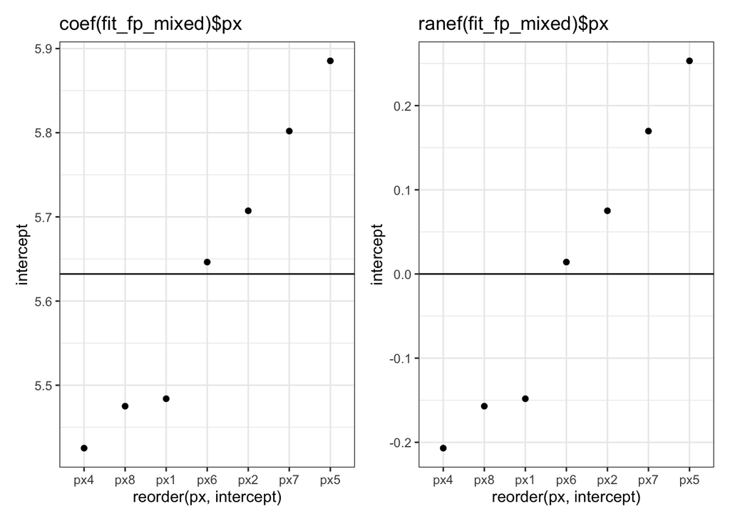

```r
fig_coef + fig_ranef
```

## 4.4 Variance-Covariance matrix

- a.k.a., your random effects structure (RES)

```r
VarCorr(fit_fp_mixed)
```

```
 Groups   Name        Std.Dev.
 px       (Intercept) 0.16978
 Residual             0.40128
```

```r
summary(fit_fp_mixed)$varcor
```

```
 Groups   Name        Std.Dev.
 px       (Intercept) 0.16978
 Residual             0.40128
```

# 5 Exercise

1. Add by-item random intercept to our model. Call this model `fit_fp_1`.
2. Explore the model. What differences do you see compared to `fit_fp_mixed`?

```r
fit_fp_1 <-
  df_crit_verb %>%
  lmer(log(fp) ~ lifetime*tense +
         (1|px) +
         (1|item_id),
       data = .,
       REML = F)
```

```r
VarCorr(fit_fp_1) %>%
  as_tibble() %>%
  select(-var2) %>%
  dplyr::rename(Group = grp,
         Name = var1,
         Variance = vcov,
         StdDev = sdcor) %>%
  kable(digits = 2) %>%
  kable_styling()
```

| Group | Name | Variance | StdDev |
| --- | --- | --- | --- |
| item_id | (Intercept) | 0.01 | 0.08 |
| px | (Intercept) | 0.03 | 0.17 |
| Residual | NA | 0.15 | 0.39 |

```r
ranef(fit_fp_1)$px %>%
  left_join(ranef(fit_fp_mixed)$px)
```

```
  (Intercept)
1 -0.14904214
2  0.07586505
3 -0.20789761
4  0.25458612
5  0.01432509
6  0.16980551
7 -0.15764202
```

```r
ranef(fit_fp_1)$px
```

```
    (Intercept)
px1 -0.14904214
px2  0.07586505
px4 -0.20789761
px5  0.25458612
px6  0.01432509
px7  0.16980551
px8 -0.15764202
```

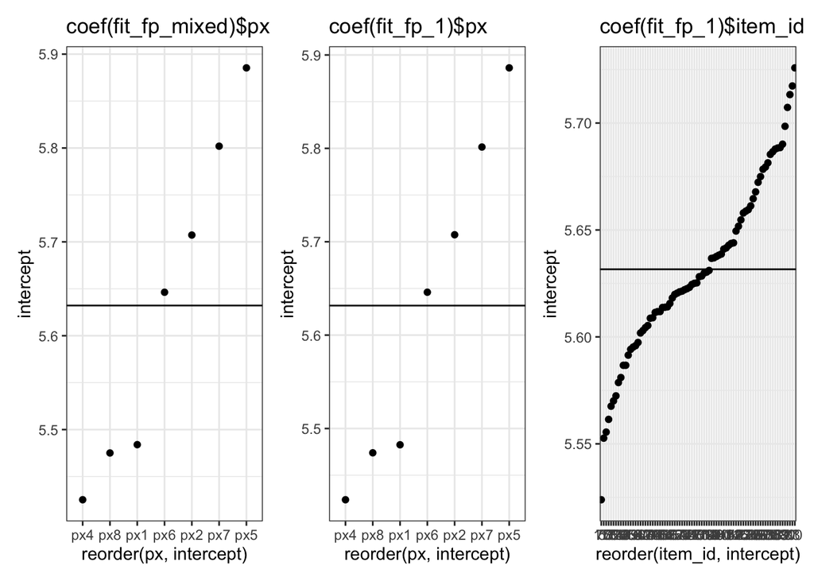

```r
(fig_coef + fig_coef_1 + fig_coef_1_item)
```

# 6 Random slopes

- so far we’ve fit *intercepts-only* model
  - there’s a lot of discussion about the dangers of fitting such models
  - they’ve been shown to dramatically increase Type I error

## 6.1 Keep It Maximal

- since Barr et al. (2013), many psycholinguists blindly fit the most maximal model plausible
  - ‘maximal’ in that it includes all random slopes

```r
fit_fp_mm <-
  df_crit_verb %>%
  lmer(log(fp) ~ lifetime*tense +
         (1 + lifetime*tense|px) +
         (1 + lifetime*tense|item_id),
       data = ., REML = F)
```

```
boundary (singular) fit: see help('isSingular')
```

- we get a warning: `boundary (singular) fit: see help('isSingular')`
  - this means our model is overparameterised/overfit
- this is an invitation to take a deeper look into the variance-covariance matrix

## 6.2 VarCorr

```r
VarCorr(fit_fp_mm)
```

```r
> VarCorr(fit_fp_mm)
 Groups   Name             Std.Dev. Corr
 item_id  (Intercept)      0.089969
          lifetime1        0.090608 0.915
          tense1           0.101374 0.981  0.976
          lifetime1:tense1 0.047890 0.837  0.546  0.717
 px       (Intercept)      0.170479
          lifetime1        0.047298 -0.382
          tense1           0.047038 -0.405  1.000
          lifetime1:tense1 0.101182  0.030 -0.935 -0.926
 Residual                  0.382558
```

### 6.2.1 Pilot data

- pilot data will tend to only converge with intercepts-only models
  - this is because we don’t have many data points per cell
- in other words, for each level of participant or item, we don’t have enough data to fit a slope
  - item: each of the 8 participants contribute 1 data point to each item
    - but only in one condition
  - so item 1 will have 8 data points: two for each condition (but we even dropped 1 participant!)
    - difficult to fit a `lifetime` slope for participants when you only have 4 observations for each level

```r
class(fit_fp_mm) <- "lmerMod"
random_params <- broom.mixed::tidy(fit_fp_mm, effect = "ran_pars")
```

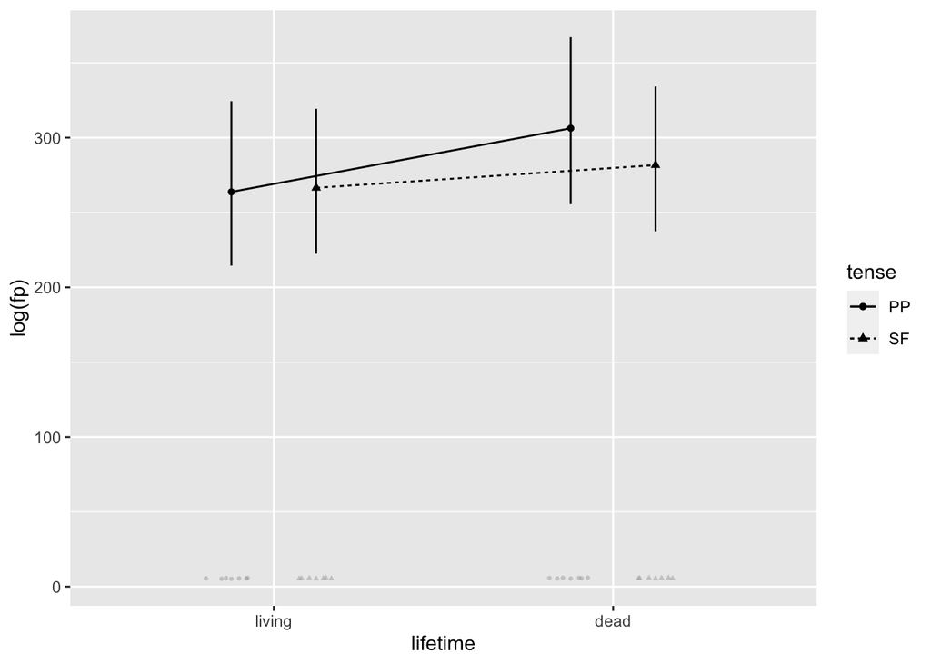

```r
afex_plot(fit_fp_mm, "lifetime", "tense", id = "px",
          data_geom = ggbeeswarm::geom_quasirandom,
          data_arg = list(
            dodge.width = 0.5,  ## needs to be same as dodge
            cex = 0.8,
            color = "darkgrey"))
```

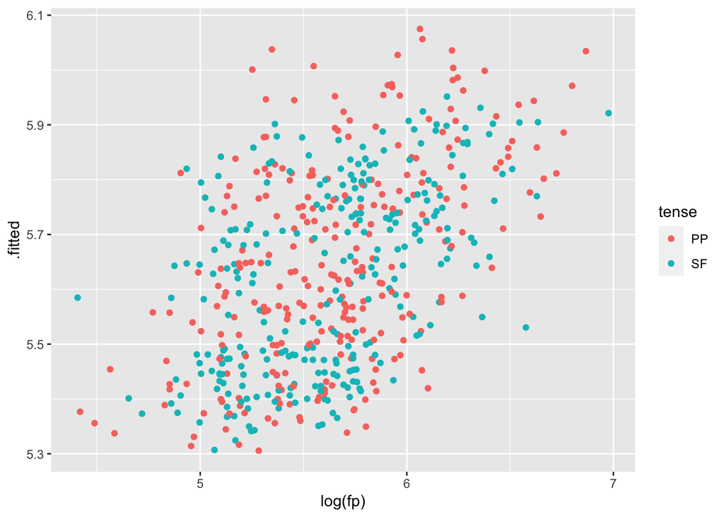

```r
augment(fit_fp_1, data = df_crit_verb[df_crit_verb$fp > 0,]) %>%
  ggplot(aes(x = log(fp), y = .fitted, colour = tense)) +
  geom_point()
```

# References

Barr, D. J., Levy, R., Scheepers, C., & Tily, H. J. (2013). Random effects structure for confirmatory hypothesis testing: Keep it maximal. *Journal of Memory and Language*, *68*(3), 255–278. https://doi.org/10.1016/j.jml.2012.11.001

Winter, B. (2014). *A very basic tutorial for performing linear mixed effects analyses (Tutorial 2)*. https://bodowinter.com/tutorial/bw_LME_tutorial2.pdf